# Project - missing data analysis

Anna Andreychenko

2025-01-16

# Визуализируем пропуски

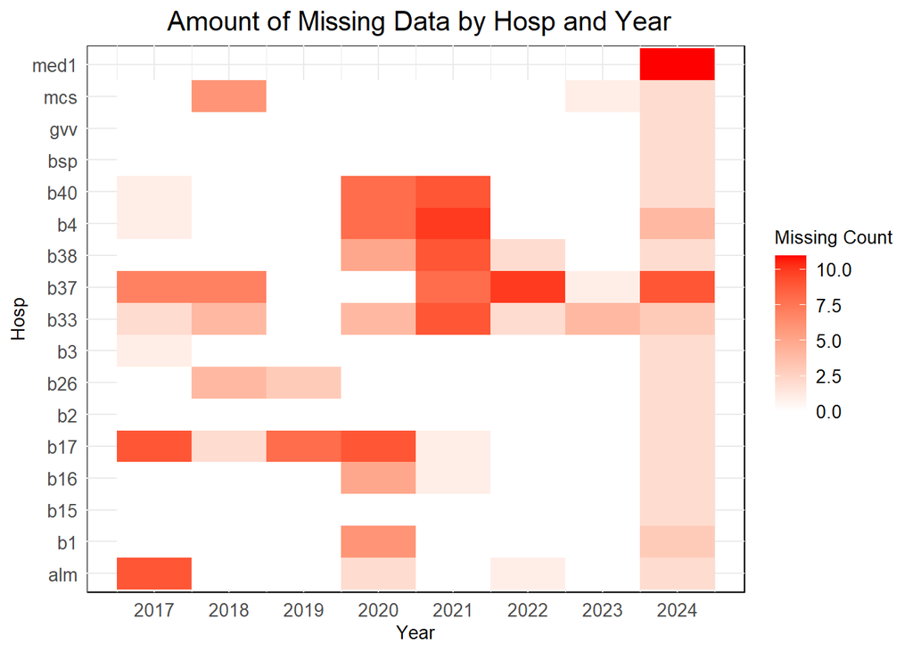

Наблюдение: В ковидные года 2020 и 2021 много пропусков.

# Общегодовая загрузка по городу

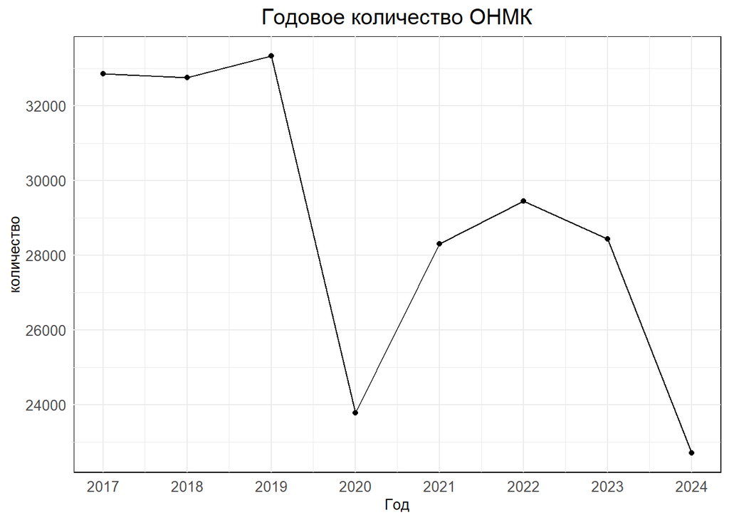

# Общегодовая загрузка по госпитализациям по городу

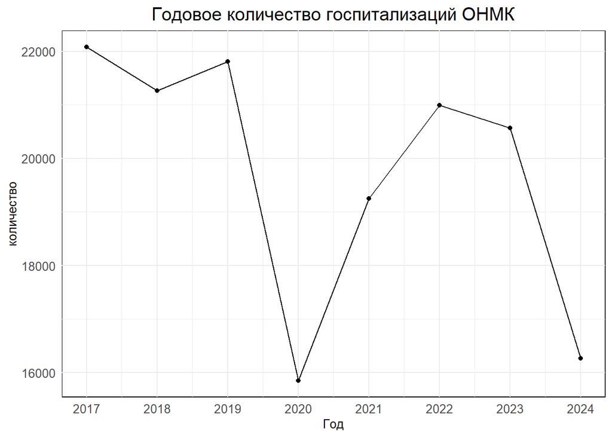

# Динамика тромболизиса и летальных исходов

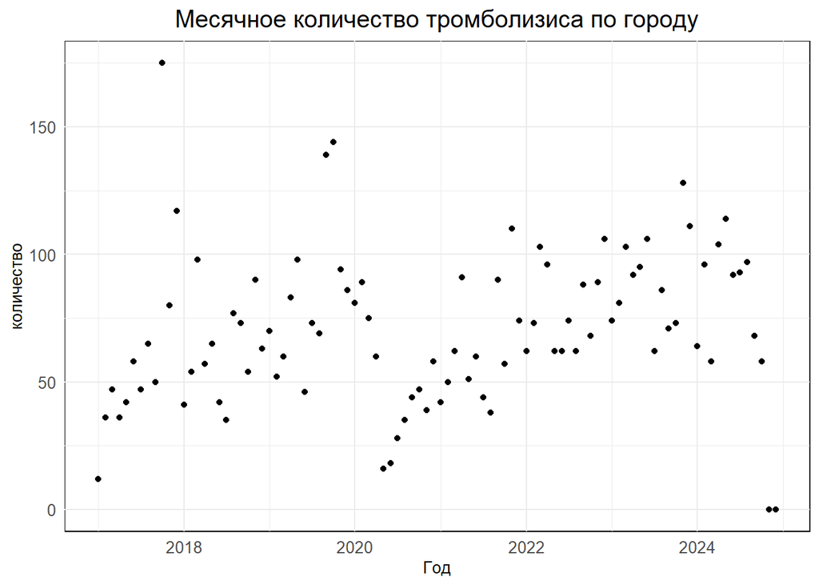

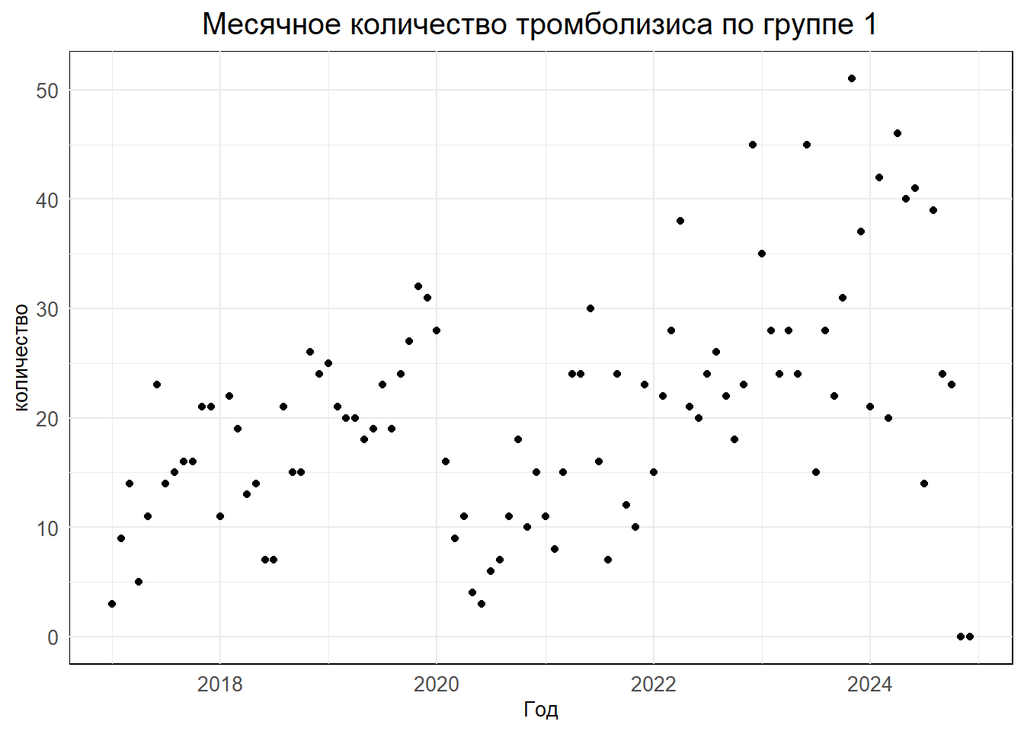

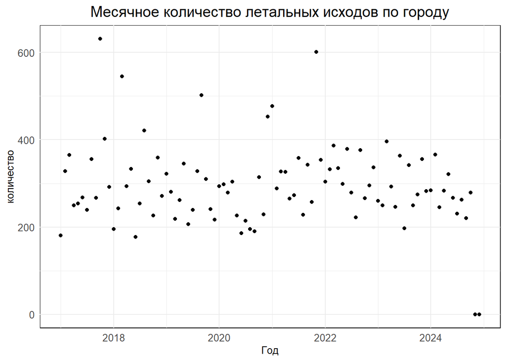

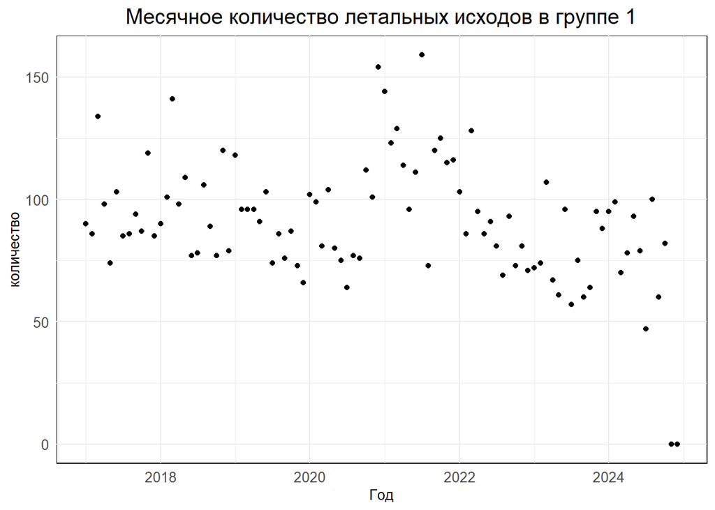

# Визуализируем данные по месяцам и годам

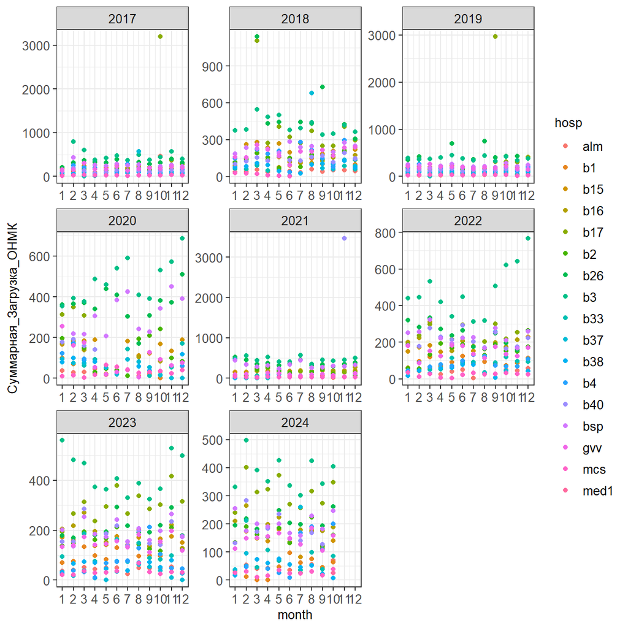

Наблюдение: присутствуют выбросы, необходимо проверить

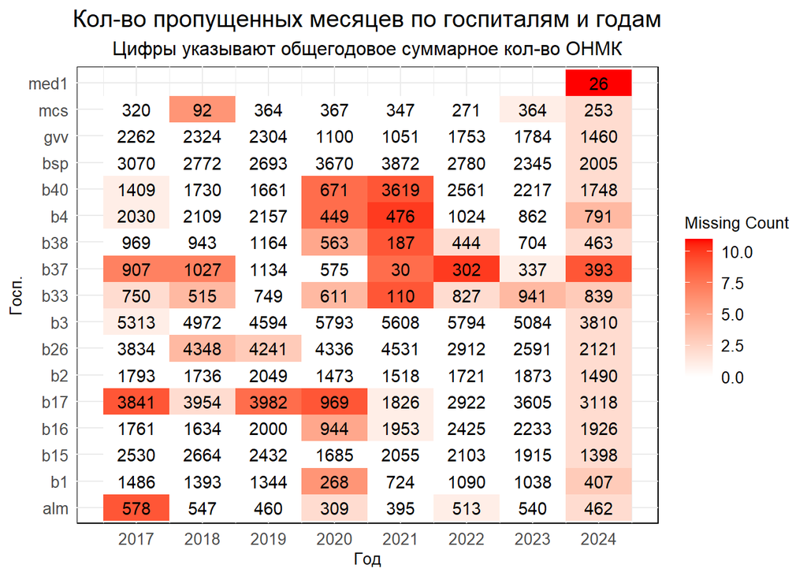

Наблюдение: присутствууте необычный рост или спад общегодового количества суммарной загрузки ОНМК у некоторых госпиталей (b40, b 26).  
Выделим группы госпиталей:  
group1 = нет пропусков gvv, bsp, b2, b15  
group2 = есть некоторые пропуски, но нет резких (кратных) скачков в общегодовом кол-ве: b3,b26  
group3 = есть некоторые пропуски, но нет резких (кратных) скачков в общегодовом кол-ве (за исключением ковидных годов 2020,2021): alm, b16, b1  
group4 = Ковидные госпиталя? b4, b38, b37, b33  
group5 = b40, b17  
group6 = mcs  
med1 - исключаем

# Динамика годового ОНМК в группах

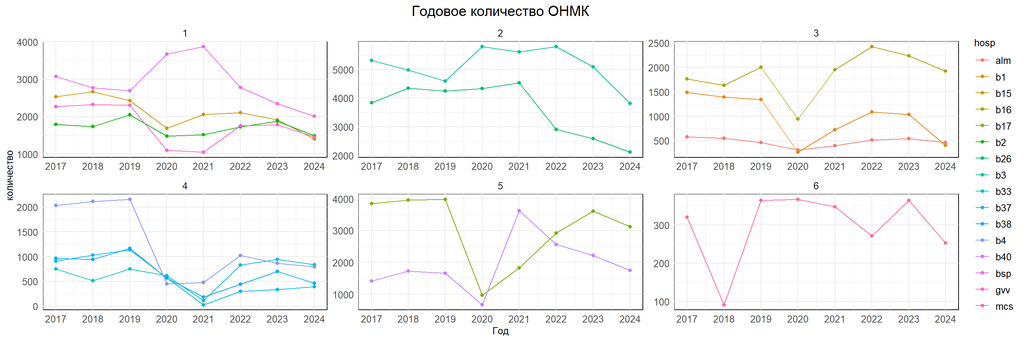

# Пропуски по месяцам в группе 2

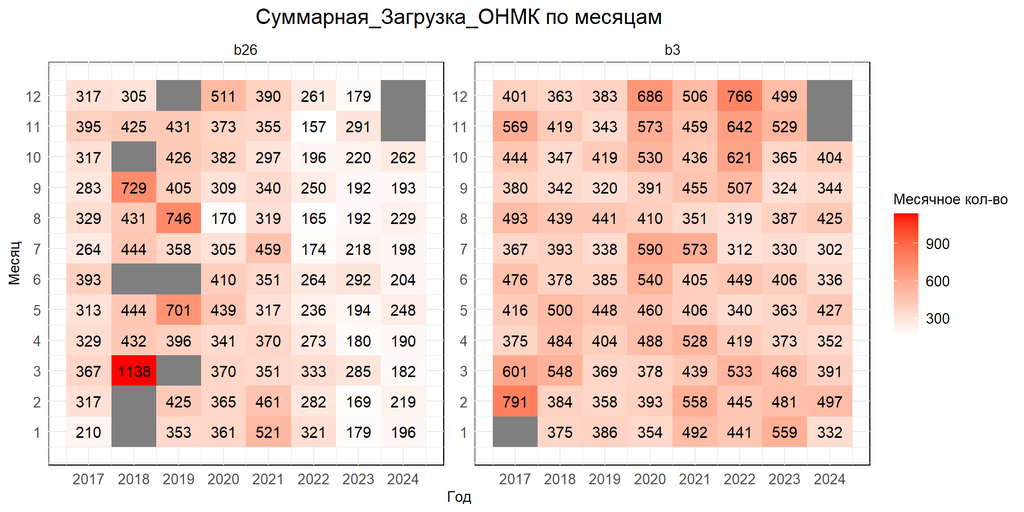

Предложение: исключить года 2018, 2019 у b26 и 2017 у b3 (либо заполнить в той же пропроции, что и 2018, 2019 годах, сохранив общее число за 1,2 месяц)

# Пропуски по месяцам в группе 3

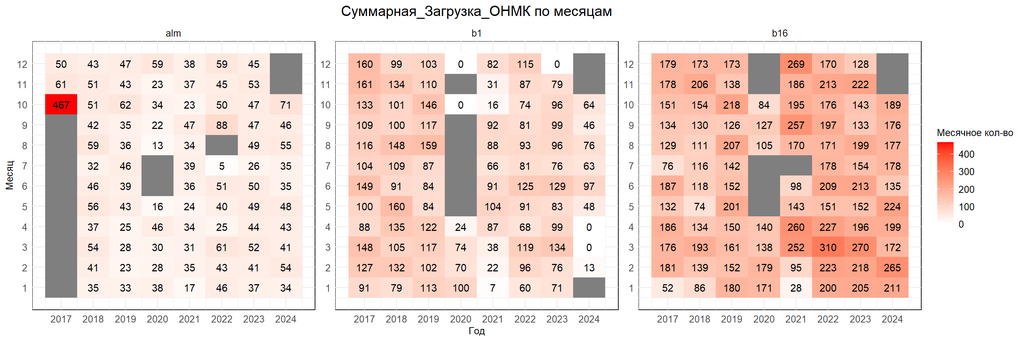

Предложение: исключить у alm 2017, 2020, 2022,  
Почему у b1 есть 0? исключить 2020, 2021, 2024?

# Пропуски по месяцам в группе 4

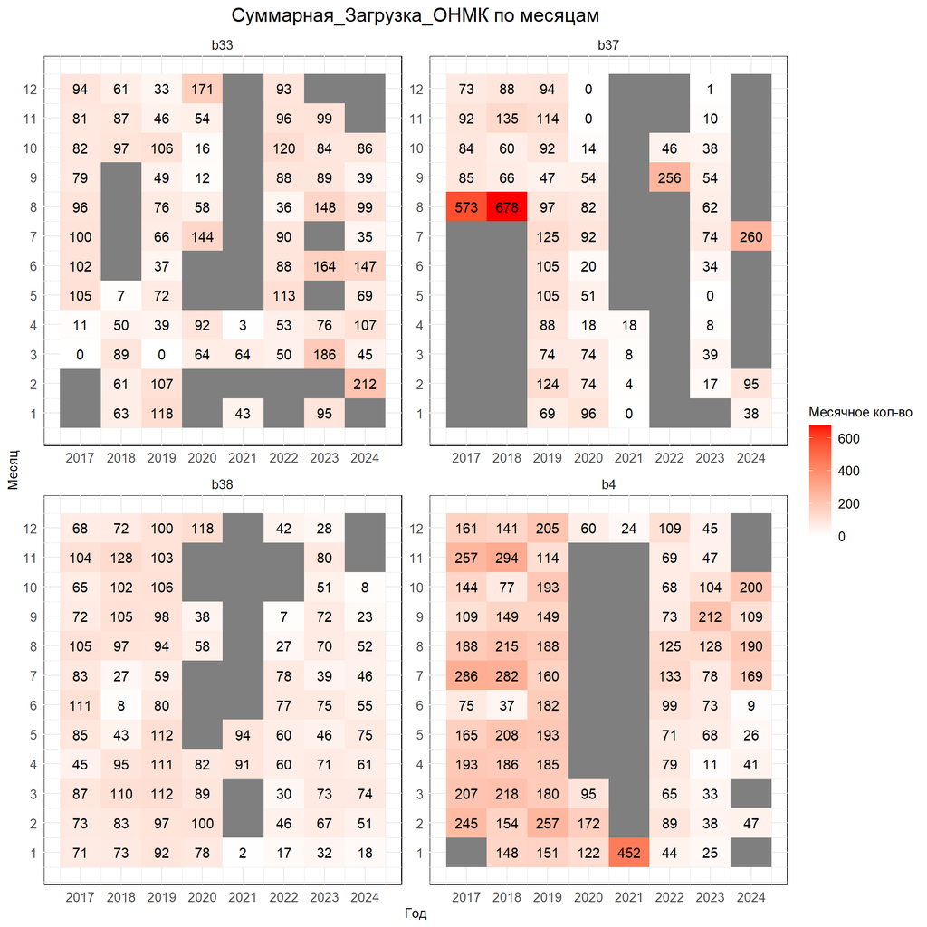

Предложение:

Исключить у b33 и b37 все года кроме 2019, у b38 - 2020-2022, b4 в 2017 заполнить средним за 2018-2019, исключить 2020, 2021. Тут также очень небольшие кол-ва в начале 2023-2024. Что с эти длеать?

# Пропуски по месяцам в группе 5

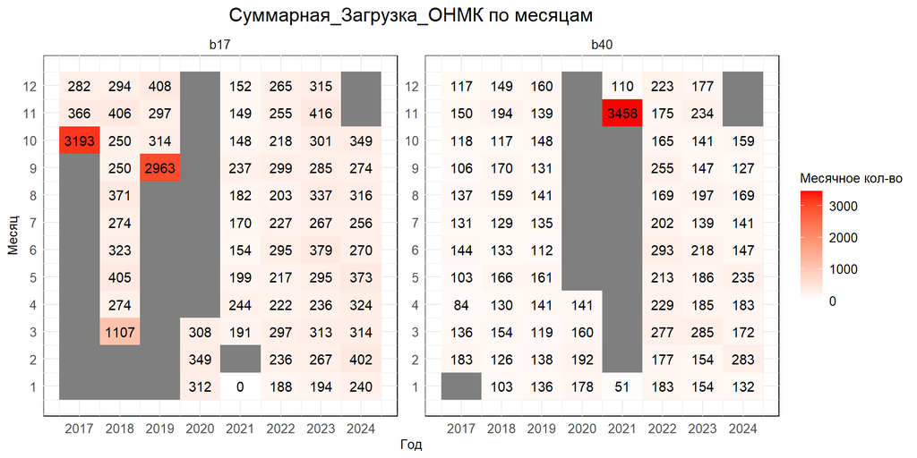

Предложение: оставить у b17 2022-2024, у b40 исключить 2020-2021, в 2017 заполнить средним за 2018-2019

# Пропуски по месяцам в группе 6

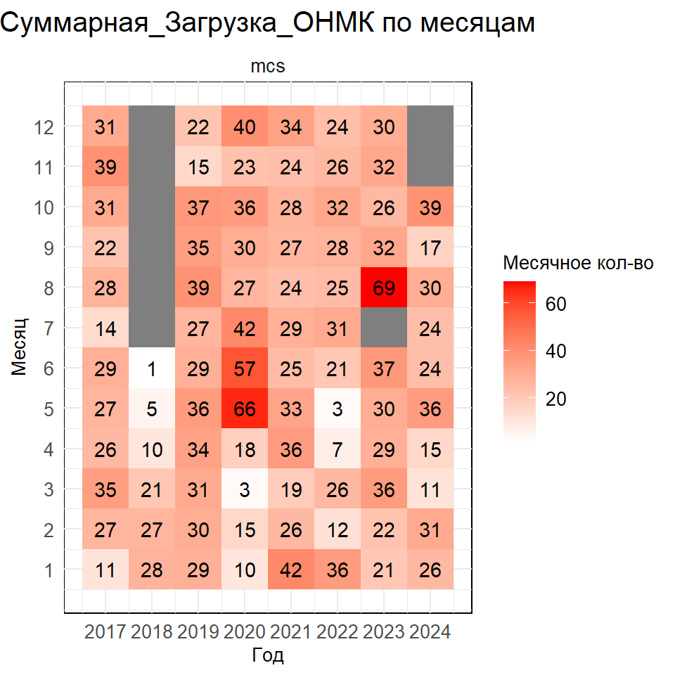

Предложение: исключить 2018, 2020-2021, в 2023 заполнить средним 7ой месяц, но сохранив общую сумму за 7 и 8.

# Общие предложения по результатам анализа:

1. Исключить госпиталь med1.
2. Исключить из анализа года 2020-2021 у всех госпиталей групп 1,4,5 и год 2020 у группы 3 независимо от наличия/отсутствия пропусков, так как там наблюдалась аномальная динамика, связанная с пандемией коронавирусной инфекции.
3. Исключить согласно предложениям по каждому госпиталю.
4. Необходимо принять решения по вопросам.